# Exploratory Analysis

### Exploratory Analysis of NYC School's Math Results.

```python
import pandas as pd
import numpy as np
from scipy.stats import zscore
from scipy import stats
import matplotlib.pyplot as plt
import seaborn as sns
import plotly.express as px
%matplotlib inline
```

**Uploading all the required files that need to be explored:**

- it is the important and first step to clean the data exhaustively in order to get the meaningful information & insights from it.
- Dataset is about the NYC School's Math Test Scores.

**Objectives of EDA is following below:**

- Uncover the structure and content of the dataset.
- Finding key variables from it.
- Detecting outliers and anomalies.
- Getting maximum insight from it.
- discovering pattern and trends.

**First Step: Uploading the datasets.**

```python
df = pd.read_excel('D:\\Data\\Profile Project\\NYC Math Test Results.xlsx', sheet_name='All_district_student')
df1 = pd.read_excel('D:\\Data\\Profile Project\\NYC Math Test Results.xlsx', sheet_name='2006_-_2012_ethnicity-dist.')
df2 = pd.read_excel('D:\\Data\\Profile Project\\NYC Math Test Results.xlsx', sheet_name='Ethnicity_Disttict')
df3 = pd.read_excel('D:\\Data\\Profile Project\\NYC Math Test Results.xlsx', sheet_name='2006-2012_Dist_allStud_math_res')
```

**Second Step: Preparing and Cleaning the datasets for analysis:**

- Handling missing data: df0.isnull().sum(), df0.dropna().
- Fixing Structural errors.
- Removing duplicate and irrelevant observations: df0.duplicated(), df0.drop_duplicates().
- Transforming the data.

**These datasets are pre-cleaned, so some of the processes of data cleaning will not be performed.**

**Dataset Number One**

```python
cols = ['District', 'Grade', 'Year', 'Dempgraphic', 'Number_Tested', 'Mean_Scale_Score', 'Proficient_Level_1', 'Level_1_%', 'Proficient_Level_2', 'Level_2_%', 'Proficient_Level_3', 'Level_3_%', 'Proficient_Level_4', 'Level_4_%', 'Proficient_Level_3+level_4', 'Level-3+4%']
df.columns=cols
df3.columns=cols
df0 = pd.concat([df,df3], axis=0, ignore_index=True)
df0 = df0.round(decimals=2)
```

```python
df0 = df0.drop(df0.index[df0['Grade']=='All Grades'])
df0 = df0.reset_index().drop(['index'], axis=1)
df0.info()
```

```
<class 'pandas.core.frame.DataFrame'>
RangeIndex: 2688 entries, 0 to 2687
Data columns (total 16 columns):
 #   Column                      Non-Null Count  Dtype
---  ------                      --------------  -----
 0   District                    2688 non-null   int64
 1   Grade                       2688 non-null   object
 2   Year                        2688 non-null   int64
 3   Dempgraphic                 2688 non-null   object
 4   Number_Tested               2688 non-null   int64
 5   Mean_Scale_Score            2688 non-null   float64
 6   Proficient_Level_1          2688 non-null   int64
 7   Level_1_%                   2688 non-null   float64
 8   Proficient_Level_2          2688 non-null   int64
 9   Level_2_%                   2688 non-null   float64
 10  Proficient_Level_3          2688 non-null   int64
 11  Level_3_%                   2688 non-null   float64
 12  Proficient_Level_4          2688 non-null   int64
 13  Level_4_%                   2688 non-null   float64
 14  Proficient_Level_3+level_4  2688 non-null   int64
 15  Level-3+4%                  2688 non-null   float64
dtypes: float64(6), int64(8), object(2)
memory usage: 336.1+ KB
```

```python
df0
```

|  | District | Grade | Year | Dempgraphic | Number_Tested | Mean_Scale_Score | Proficient_Level_1 | Level_1_% | Proficient_Level_2 | Level_2_% | Proficient_Level_3 | Level_3_% | Proficient_Level_4 | Level_4_% | Proficient_Level_3+level_4 | Level-3+4% |
| --- | --- | --- | --- | --- | --- | --- | --- | --- | --- | --- | --- | --- | --- | --- | --- | --- |
| 0 | 1 | 3 | 2013 | All Students | 887 | 306.69 | 249 | 28.07 | 266 | 29.99 | 179 | 20.18 | 193 | 21.76 | 372 | 41.94 |
| 1 | 1 | 3 | 2014 | All Students | 845 | 307.95 | 225 | 26.63 | 223 | 26.39 | 204 | 24.14 | 193 | 22.84 | 397 | 46.98 |
| 2 | 1 | 3 | 2015 | All Students | 765 | 309.46 | 221 | 28.89 | 175 | 22.88 | 168 | 21.96 | 201 | 26.27 | 369 | 48.24 |
| 3 | 1 | 3 | 2016 | All Students | 743 | 313.55 | 184 | 24.76 | 178 | 23.96 | 141 | 18.98 | 240 | 32.30 | 381 | 51.28 |
| 4 | 1 | 3 | 2017 | All Students | 726 | 311.88 | 185 | 25.48 | 166 | 22.87 | 152 | 20.94 | 223 | 30.72 | 375 | 51.65 |
| ... | ... | ... | ... | ... | ... | ... | ... | ... | ... | ... | ... | ... | ... | ... | ... | ... |
| 2683 | 32 | 8 | 2008 | All Students | 1517 | 650.00 | 202 | 13.30 | 528 | 34.80 | 686 | 45.20 | 101 | 6.70 | 787 | 51.90 |
| 2684 | 32 | 8 | 2009 | All Students | 1590 | 662.00 | 106 | 6.70 | 406 | 25.50 | 923 | 58.10 | 155 | 9.70 | 1078 | 67.80 |
| 2685 | 32 | 8 | 2010 | All Students | 1600 | 662.00 | 314 | 19.60 | 698 | 43.60 | 462 | 28.90 | 126 | 7.90 | 588 | 36.80 |
| 2686 | 32 | 8 | 2011 | All Students | 1541 | 664.00 | 215 | 14.00 | 708 | 45.90 | 498 | 32.30 | 120 | 7.80 | 618 | 40.10 |
| 2687 | 32 | 8 | 2012 | All Students | 1295 | 666.00 | 184 | 14.20 | 564 | 43.60 | 428 | 33.10 | 119 | 9.20 | 547 | 42.20 |

2688 rows × 16 columns

**Third Step: Filtering and removing outliers.**  
There are several techniques for detecting outliers such as:

1. Sorting the data points.
2. Data Vizualization.
3. Statistical methods.

**Interquartile Range method will be used in these datasets.**

The Interquartile range method is used in this dataset.

```python
df_outlier = df0.astype({'District':'str', 'Year':'int', 'Grade':'str', 'Dempgraphic':'str'})
category = df_outlier.iloc[:, 0:4]
numeric=df_outlier.iloc[:,4:17]
Q1 = numeric.quantile(0.25)
Q3 = numeric.quantile(0.75)
IQR = Q3-Q1
print(IQR)
```

```
Number_Tested                 1520.0000
Mean_Scale_Score               366.3300
Proficient_Level_1             462.0000
Level_1_%                       28.8950
Proficient_Level_2             485.2500
Level_2_%                       12.1400
Proficient_Level_3             645.5000
Level_3_%                       22.9725
Proficient_Level_4             522.2500
Level_4_%                       18.2825
Proficient_Level_3+level_4    1195.2500
Level-3+4%                      36.2000
dtype: float64
```

```python
# All the outliers in the dataset:
outliers = numeric[((numeric<(Q1-1.5*IQR)) | (numeric>(Q3+1.5*IQR)))]
outliers.count()
```

```
Number_Tested                   0
Mean_Scale_Score                0
Proficient_Level_1            107
Level_1_%                       0
Proficient_Level_2             39
Level_2_%                      23
Proficient_Level_3             73
Level_3_%                       0
Proficient_Level_4             33
Level_4_%                      33
Proficient_Level_3+level_4     18
Level-3+4%                      0
dtype: int64
```

```python
print(outliers.max())
print(outliers.min())
```

```
Number_Tested                    NaN
Mean_Scale_Score                 NaN
Proficient_Level_1            2298.0
Level_1_%                        NaN
Proficient_Level_2            1885.0
Level_2_%                       53.5
Proficient_Level_3            2913.0
Level_3_%                        NaN
Proficient_Level_4            1842.0
Level_4_%                       72.0
Proficient_Level_3+level_4    4207.0
Level-3+4%                       NaN
dtype: float64
Number_Tested                     NaN
Mean_Scale_Score                  NaN
Proficient_Level_1            1318.00
Level_1_%                         NaN
Proficient_Level_2            1549.00
Level_2_%                        0.60
Proficient_Level_3            1911.00
Level_3_%                         NaN
Proficient_Level_4            1425.00
Level_4_%                       54.04
Proficient_Level_3+level_4    3441.00
Level-3+4%                        NaN
dtype: float64
```

```python
# Removing outliers from dataset
outlier = numeric[~((numeric<(Q1-1.5*IQR)) | (numeric>(Q3+1.5*IQR)))]
outlier.count()
```

```
Number_Tested                 2688
Mean_Scale_Score              2688
Proficient_Level_1            2581
Level_1_%                     2688
Proficient_Level_2            2649
Level_2_%                     2665
Proficient_Level_3            2615
Level_3_%                     2688
Proficient_Level_4            2655
Level_4_%                     2655
Proficient_Level_3+level_4    2670
Level-3+4%                    2688
dtype: int64
```

```python
print(outlier.max())
print(outlier.min())
```

```
Number_Tested                 5061.00
Mean_Scale_Score               723.00
Proficient_Level_1            1317.00
Level_1_%                       71.67
Proficient_Level_2            1538.00
Level_2_%                       53.10
Proficient_Level_3            1900.00
Level_3_%                       72.70
Proficient_Level_4            1422.00
Level_4_%                       53.53
Proficient_Level_3+level_4    3413.00
Level-3+4%                      99.30
dtype: float64
Number_Tested                 322.00
Mean_Scale_Score              262.20
Proficient_Level_1              1.00
Level_1_%                       0.10
Proficient_Level_2             11.00
Level_2_%                       4.60
Proficient_Level_3             19.00
Level_3_%                       3.46
Proficient_Level_4              1.00
Level_4_%                       0.16
Proficient_Level_3+level_4     24.00
Level-3+4%                      3.76
dtype: float64
```

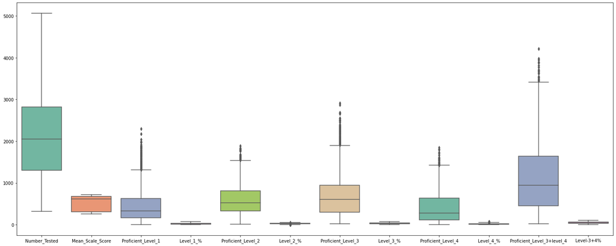

```python
plt.figure(figsize=(25,10))
sns.boxplot(data=numeric, palette="Set2");
```

```python
outlier_removed_data = pd.concat([category, outlier], axis=1)
```

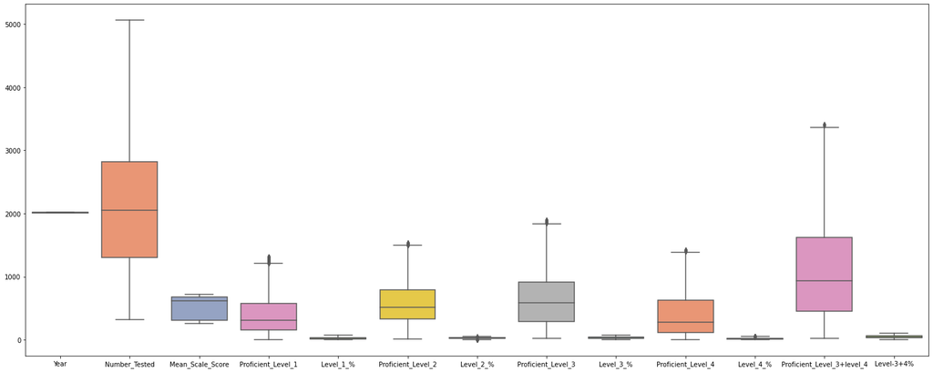

```python
plt.figure(figsize=(25,10))
sns.boxplot(data=outlier_removed_data, palette="Set2");
```

**Dataset Number Two**  
Similar procedures have been performed on this dataset as in the previous dataset.

```python
df1.columns = cols
df2.columns=cols
df7 = pd.concat([df1, df2], axis=0, ignore_index=True)
```

```python
df7 = df7.drop(df7.index[df7['Grade']=='All Grades'])
df7 = df7.reset_index().drop(['index'], axis=1)
df7 = df7.replace('s',0)
df7 = df7.round(decimals=2)
```

```python
df7 = df7.drop(df7.index[df7['Mean_Scale_Score']==0])
df7.reset_index()
df7.info()
```

```
<class 'pandas.core.frame.DataFrame'>
Int64Index: 10608 entries, 0 to 10751
Data columns (total 16 columns):
 #   Column                      Non-Null Count  Dtype
---  ------                      --------------  -----
 0   District                    10608 non-null  int64
 1   Grade                       10608 non-null  int64
 2   Year                        10608 non-null  int64
 3   Dempgraphic                 10608 non-null  object
 4   Number_Tested               10608 non-null  int64
 5   Mean_Scale_Score            10608 non-null  float64
 6   Proficient_Level_1          10608 non-null  int64
 7   Level_1_%                   10608 non-null  float64
 8   Proficient_Level_2          10608 non-null  int64
 9   Level_2_%                   10608 non-null  float64
 10  Proficient_Level_3          10608 non-null  int64
 11  Level_3_%                   10608 non-null  float64
 12  Proficient_Level_4          10608 non-null  int64
 13  Level_4_%                   10608 non-null  float64
 14  Proficient_Level_3+level_4  10608 non-null  int64
 15  Level-3+4%                  10608 non-null  float64
dtypes: float64(6), int64(9), object(1)
memory usage: 1.4+ MB
```

```python
df7
```

|  | District | Grade | Year | Dempgraphic | Number_Tested | Mean_Scale_Score | Proficient_Level_1 | Level_1_% | Proficient_Level_2 | Level_2_% | Proficient_Level_3 | Level_3_% | Proficient_Level_4 | Level_4_% | Proficient_Level_3+level_4 | Level-3+4% |
| --- | --- | --- | --- | --- | --- | --- | --- | --- | --- | --- | --- | --- | --- | --- | --- | --- |
| 0 | 1 | 3 | 2006 | Asian | 155 | 704.00 | 4 | 2.60 | 4 | 2.60 | 68 | 43.90 | 79 | 51.00 | 147 | 94.80 |
| 1 | 1 | 3 | 2006 | Black | 185 | 659.00 | 21 | 11.40 | 47 | 25.40 | 104 | 56.20 | 13 | 7.00 | 117 | 63.20 |
| 2 | 1 | 3 | 2006 | Hispanic | 494 | 664.00 | 46 | 9.30 | 111 | 22.50 | 264 | 53.40 | 73 | 14.80 | 337 | 68.20 |
| 3 | 1 | 3 | 2006 | White | 94 | 702.00 | 1 | 1.10 | 5 | 5.30 | 45 | 47.90 | 43 | 45.70 | 88 | 93.60 |
| 4 | 1 | 3 | 2007 | Asian | 131 | 703.00 | 2 | 1.50 | 4 | 3.10 | 58 | 44.30 | 67 | 51.10 | 125 | 95.40 |
| ... | ... | ... | ... | ... | ... | ... | ... | ... | ... | ... | ... | ... | ... | ... | ... | ... |
| 10747 | 32 | 8 | 2015 | White | 30 | 285.57 | 14 | 46.67 | 13 | 43.33 | 2 | 6.67 | 1 | 3.33 | 3 | 10.00 |
| 10748 | 32 | 8 | 2016 | White | 12 | 286.75 | 6 | 50.00 | 4 | 33.33 | 2 | 16.67 | 0 | 0.00 | 2 | 16.67 |
| 10749 | 32 | 8 | 2017 | White | 13 | 279.15 | 7 | 53.85 | 4 | 30.77 | 2 | 15.38 | 0 | 0.00 | 2 | 15.38 |
| 10750 | 32 | 8 | 2018 | White | 17 | 603.35 | 5 | 29.41 | 5 | 29.41 | 5 | 29.41 | 2 | 11.76 | 7 | 41.18 |
| 10751 | 32 | 8 | 2019 | White | 13 | 591.92 | 5 | 38.46 | 5 | 38.46 | 2 | 15.38 | 1 | 7.69 | 3 | 23.08 |

10608 rows × 16 columns

```python
categorical = df7.iloc[:, 0:4]
numerical = df7.iloc[:, 4:17]
```

```
Number_Tested                     AxesSubplot(0.125,0.71587;0.227941x0.16413)
Mean_Scale_Score               AxesSubplot(0.398529,0.71587;0.227941x0.16413)
Proficient_Level_1             AxesSubplot(0.672059,0.71587;0.227941x0.16413)
Level_1_%                        AxesSubplot(0.125,0.518913;0.227941x0.16413)
Proficient_Level_2            AxesSubplot(0.398529,0.518913;0.227941x0.16413)
Level_2_%                     AxesSubplot(0.672059,0.518913;0.227941x0.16413)
Proficient_Level_3               AxesSubplot(0.125,0.321957;0.227941x0.16413)
Level_3_%                     AxesSubplot(0.398529,0.321957;0.227941x0.16413)
Proficient_Level_4            AxesSubplot(0.672059,0.321957;0.227941x0.16413)
Level_4_%                           AxesSubplot(0.125,0.125;0.227941x0.16413)
Proficient_Level_3+level_4       AxesSubplot(0.398529,0.125;0.227941x0.16413)
Level-3+4%                       AxesSubplot(0.672059,0.125;0.227941x0.16413)
dtype: object
```

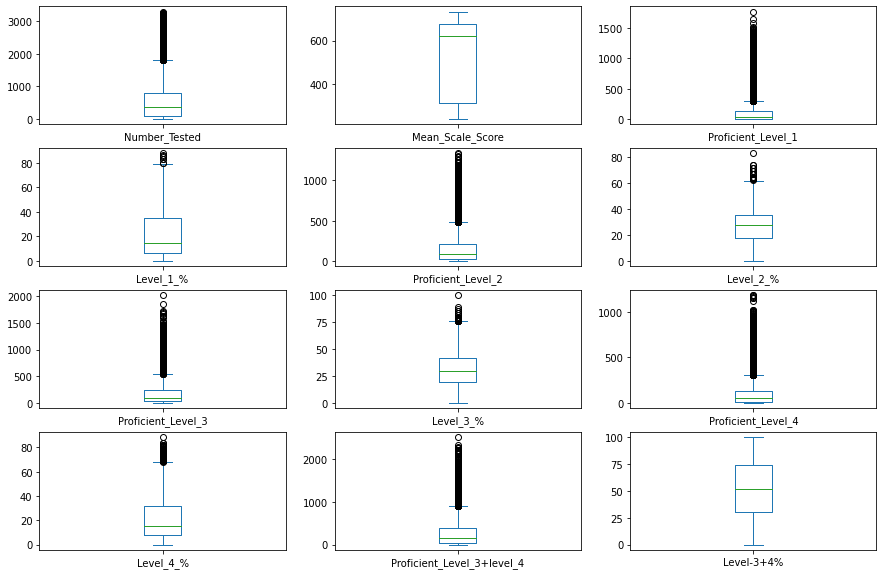

```python
numerical.plot(kind="box", subplots=True, layout=(4,3), figsize=(15,10))
```

```python
q1= numerical.quantile(0.25)
q3=numerical.quantile(0.75)
iqr=q3-q1
cleandff = numerical[~((numerical<(q1-1.5*iqr)) | (numerical>(q3+1.5*iqr)))]
clean_data = pd.concat([categorical, cleandff], axis=1)
```

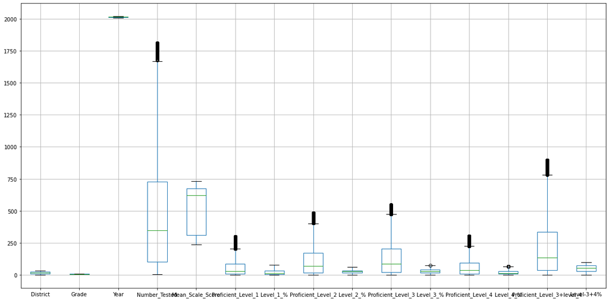

```python
clean_data.boxplot(figsize=(20,10));
```

**NOTE - Some data poins are still reflecting as a outlier in the plots in both datasets. But these data points are valid observations and these are validating other variables in the datasets. That's why, these haven't been discarded.**

Now both the datasets are cleaned.

**Next step is QA and validate the datasets.**

1. Does the data make sense?
2. Does it prove or disprove your theory and expected outcomes.
3. Can you find the trends and patterns in the data that can help you unleash the insights or develop a new theory upon it.
4. if not, what is the issue?
5. is it because of data quality or in other respects.

**This can be achieved by asking analytical queries and data visualization.**

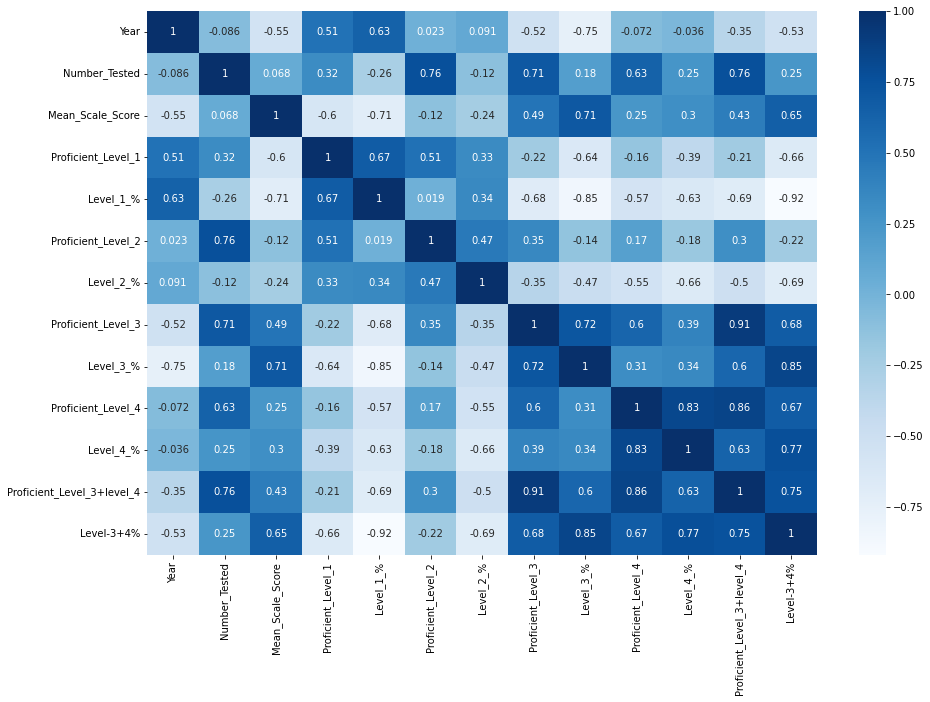

```python
# Correlation tool can find the positive and negative relation between the variables.
plt.figure(figsize=(15,10))
sns.heatmap(outlier_removed_data.corr(),cbar=True,annot=True,cmap='Blues');
```

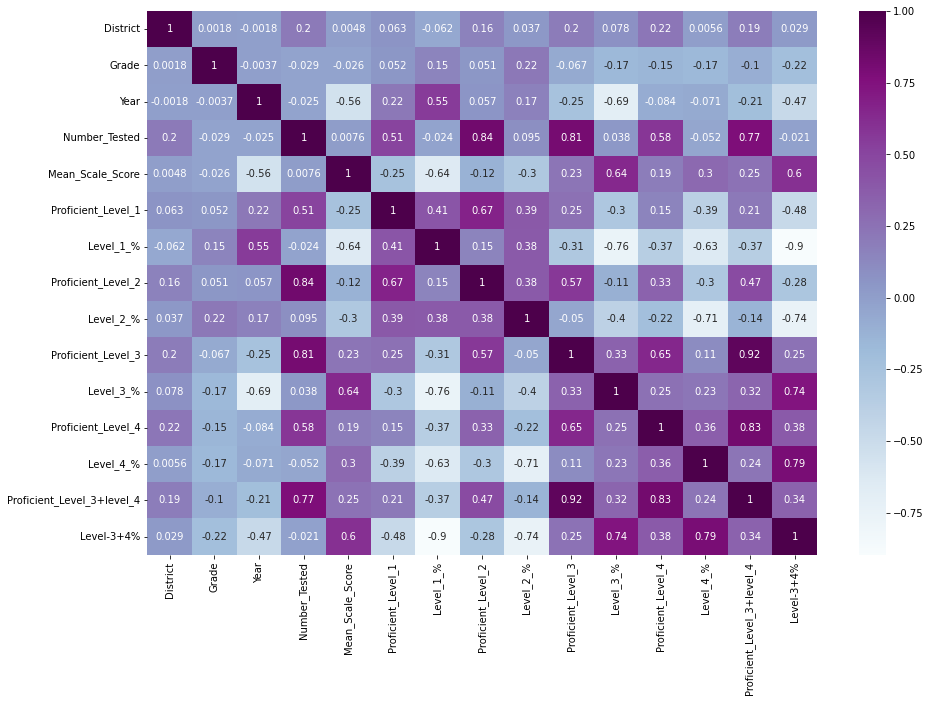

```python
plt.figure(figsize=(15,10))
sns.heatmap(clean_data.corr(),cbar=True,annot=True,cmap='BuPu');
```

```python
# Can create comparison, relationship and correlation charts to extract the insight from the data.
outlier_removed_data.head(2)
```

|  | District | Grade | Year | Dempgraphic | Number_Tested | Mean_Scale_Score | Proficient_Level_1 | Level_1_% | Proficient_Level_2 | Level_2_% | Proficient_Level_3 | Level_3_% | Proficient_Level_4 | Level_4_% | Proficient_Level_3+level_4 | Level-3+4% |
| --- | --- | --- | --- | --- | --- | --- | --- | --- | --- | --- | --- | --- | --- | --- | --- | --- |
| 0 | 1 | 3 | 2013 | All Students | 887 | 306.69 | 249.0 | 28.07 | 266.0 | 29.99 | 179.0 | 20.18 | 193.0 | 21.76 | 372.0 | 41.94 |
| 1 | 1 | 3 | 2014 | All Students | 845 | 307.95 | 225.0 | 26.63 | 223.0 | 26.39 | 204.0 | 24.14 | 193.0 | 22.84 | 397.0 | 46.98 |

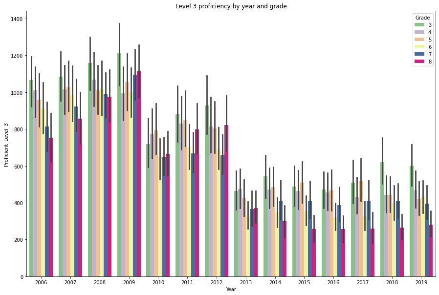

```python
plt.figure(figsize=(15,10))
sns.barplot(data=outlier_removed_data, x='Year', y='Proficient_Level_3', hue='Grade', palette="Accent")
plt.title('Level 3 proficiency by year and grade')
plt.show()
```

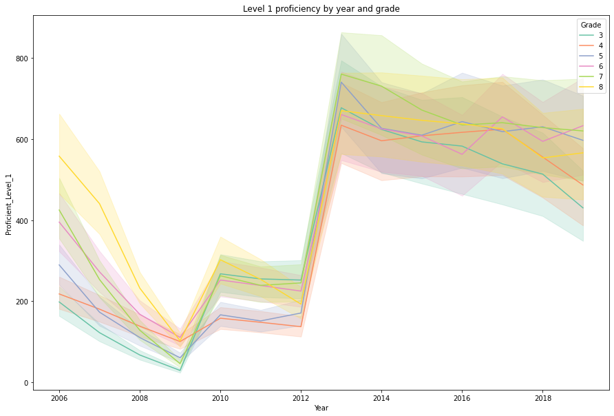

```python
plt.figure(figsize=(15,10))
sns.lineplot(data=outlier_removed_data, x='Year', y='Proficient_Level_1', hue='Grade', palette="Set2")
plt.title('Level 1 proficiency by year and grade')
plt.show()
```

```python
grouped=outlier_removed_data.groupby('Year').sum()
```

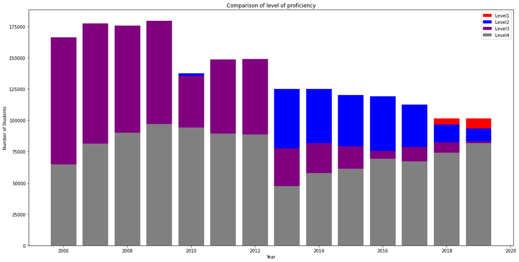

```python
plt.figure(figsize=(20,10))
plt.bar(grouped.index, grouped.Proficient_Level_1, label='Level1', color='red')
plt.bar(grouped.index, grouped.Proficient_Level_2, label='Level2', color='blue')
plt.bar(grouped.index, grouped.Proficient_Level_3, label='Level3', color='purple')
plt.bar(grouped.index, grouped.Proficient_Level_4, label='Level4', color='grey')
plt.xlabel('Year')
plt.ylabel('Number of Students')
plt.title('Comparison of level of proficiency')
plt.legend()
plt.show()
```

```python
clean_data['Grade'].astype('str')
clean_data.head(2)
```

|  | District | Grade | Year | Dempgraphic | Number_Tested | Mean_Scale_Score | Proficient_Level_1 | Level_1_% | Proficient_Level_2 | Level_2_% | Proficient_Level_3 | Level_3_% | Proficient_Level_4 | Level_4_% | Proficient_Level_3+level_4 | Level-3+4% |
| --- | --- | --- | --- | --- | --- | --- | --- | --- | --- | --- | --- | --- | --- | --- | --- | --- |
| 0 | 1 | 3 | 2006 | Asian | 155.0 | 704.0 | 4.0 | 2.6 | 4.0 | 2.6 | 68.0 | 43.9 | 79.0 | 51.0 | 147.0 | 94.8 |
| 1 | 1 | 3 | 2006 | Black | 185.0 | 659.0 | 21.0 | 11.4 | 47.0 | 25.4 | 104.0 | 56.2 | 13.0 | 7.0 | 117.0 | 63.2 |

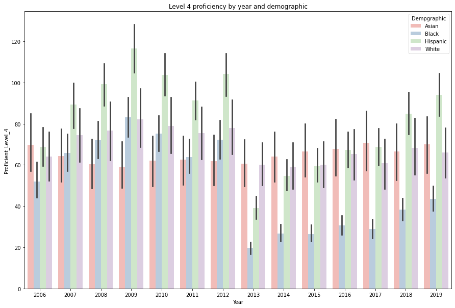

```python
plt.figure(figsize=(15,10))
sns.barplot(data=clean_data, x='Year', y='Proficient_Level_4', hue='Dempgraphic', palette="Pastel1")
plt.title('Level 4 proficiency by year and demographic')
plt.show()
```

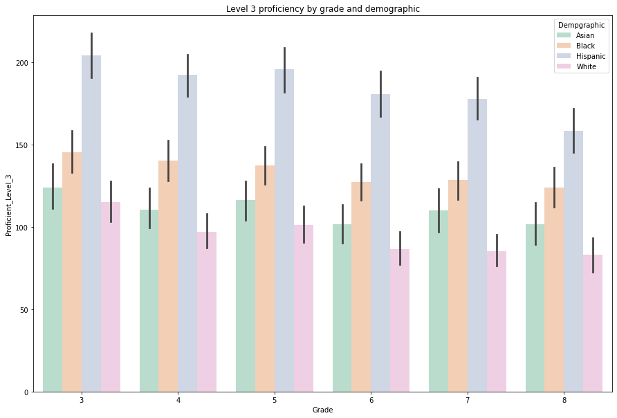

```python
plt.figure(figsize=(15,10))
sns.barplot(data=clean_data, x='Grade', y='Proficient_Level_3', hue='Dempgraphic', palette="Pastel2")
plt.title('Level 3 proficiency by grade and demographic')
plt.show()
```

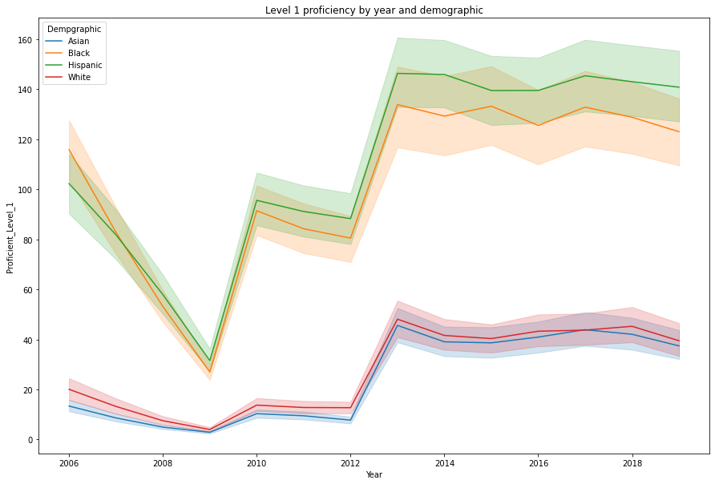

```python
plt.figure(figsize=(15,10))
sns.lineplot(data=clean_data, x='Year', y='Proficient_Level_1', hue='Dempgraphic')
plt.title('Level 1 proficiency by year and demographic')
plt.show()
```

**These datasets are ready for further analysis**.